# Religious Affiliation, Sociosexuality, and Relationship Duration

Author

Joseph Mosquera

#this is all for knitting & exporting knitted quarto/markdown #toc true adds table of contents #fold allows you to fold/unfold the generated subcode #echo true gives you the sub code that is generated

## H1: Religious affiliation & time spent living in country of birth

We predict religious affiliation will predict time spent living in country of birth.

### Variables & descriptive statistics

- **Religious affiliation (‘Religion_type’):** A categorical variable with seven groups: Christianity, Islam, Hinduism, Buddhism, Other, Judaism, & None.
- **Time Spent living in country of birth (‘Country_live_time’):** A continuous variable measuring the number of years respondents have lived in their country of birth. Valid responses range from 1-80.

```r
# Count respondents in each group.
table(h1Data$Religion_type)
```

```
Christianity        Islam     Hinduism     Buddhism        Other      Judaism
        3398         4349          157          186          364          120
        None
        4145
```

```r
# Summarize attractiveness points separately for each group.
by(h1Data$Country_live_time, h1Data$Religion_type, summary)
```

```
h1Data$Religion_type: Christianity
   Min. 1st Qu.  Median    Mean 3rd Qu.    Max.
   1.00    3.00   10.00   16.32   25.00   80.00
------------------------------------------------------------
h1Data$Religion_type: Islam
   Min. 1st Qu.  Median    Mean 3rd Qu.    Max.
   1.00   21.00   25.00   24.85   32.00   80.00
------------------------------------------------------------
h1Data$Religion_type: Hinduism
   Min. 1st Qu.  Median    Mean 3rd Qu.    Max.
  1.000   2.000   4.000   8.739  10.000  80.000
------------------------------------------------------------
h1Data$Religion_type: Buddhism
   Min. 1st Qu.  Median    Mean 3rd Qu.    Max.
   1.00    4.00    7.00   15.92   22.00   80.00
------------------------------------------------------------
h1Data$Religion_type: Other
   Min. 1st Qu.  Median    Mean 3rd Qu.    Max.
   1.00    3.00    6.00   13.03   15.25   80.00
------------------------------------------------------------
h1Data$Religion_type: Judaism
   Min. 1st Qu.  Median    Mean 3rd Qu.    Max.
   1.00    4.75   12.50   17.70   30.00   71.00
------------------------------------------------------------
h1Data$Religion_type: None
   Min. 1st Qu.  Median    Mean 3rd Qu.    Max.
   1.00    3.00   10.00   16.82   27.00   80.00
```

```r
                                                   #can do table or other functions, not just summary
```

### Graph

Figure 1 shows the distribution of years spent living in country of birth by religious affiliation. The half-violin shows the shape of the distribution, the box summarizes the median and quartiles, and the dots represent individual responses.

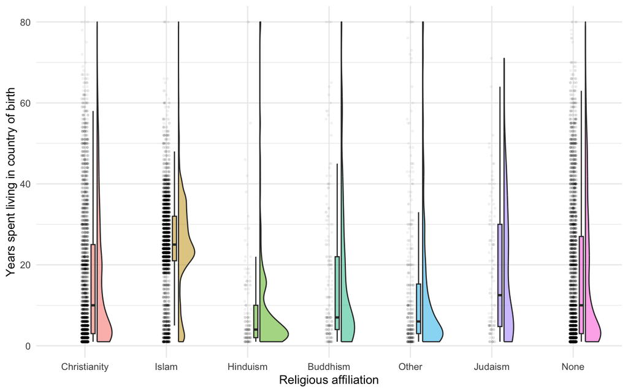

Figure 1: Time spent living in country of birth by religious affiliation.

```r
ggplot(h1Data, aes(x = Religion_type, y = Country_live_time, fill = Religion_type)) +
  geom_rain(alpha = 0.5, point.args = list(alpha = 0.04, size = 0.6)) +
  labs(x = "Religious affiliation", y = "Years spent living in country of birth") +
  theme_minimal() +
  theme(legend.position = "none")
```

## H2. Sociosexuality & relationship duration

We predict casual sexual experiences & preferences will predict relationship duration.

### Variables and descriptive statistics

- **Sociosexuality composite (‘soiComposite’):** The mean of available responses to ‘soi_behave’, ‘soi_attitude’, & ‘soi_desire’. Each item ranges from 1 to 9, with higher scores indicating more unrestricted sociosexuality.
- **Relationship duration (‘relationship_length’):** A variable representing the length of respondendts’ current relationships. Responses range from 1 to 80, with higer values indicating longer relationship duration.

This dataset includes respondents who were dating, in a committed relationship, or married.

```r
summary(h2Data[, c("soiComposite", "Relationship_length")])
```

```
  soiComposite   Relationship_length
 Min.   :1.000   Min.   : 1.000
 1st Qu.:1.333   1st Qu.: 2.000
 Median :2.667   Median : 4.000
 Mean   :3.056   Mean   : 8.214
 3rd Qu.:4.333   3rd Qu.:10.000
 Max.   :9.000   Max.   :80.000
```

### Graph

Figure 2 shows the relationship sociosexuality relationship duration Points are jittered to make overlapping responses easier to see; the recorded scores are unchanged. The line summarizes the linear trend.

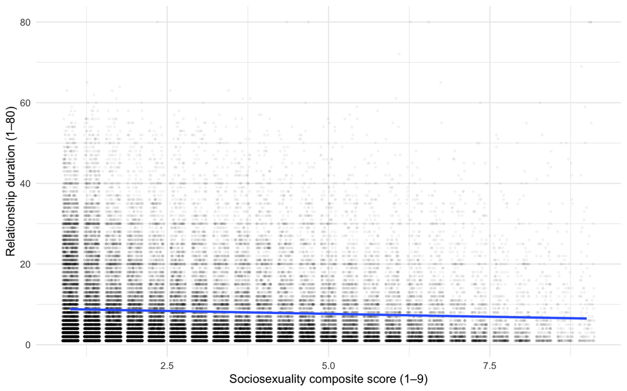

Figure 2: Sociosexuality composite scores and relationship duration.

```r
ggplot(h2Data, aes(x = soiComposite, y = Relationship_length)) +
  geom_jitter(width = .12, height = .04, alpha = .04, size = .6) +
  geom_smooth(method = "lm") +
  labs(x = "Sociosexuality composite score (1–9)",
       y = "Relationship duration (1–80)") +
  theme_minimal()
```

### Observed trend

```r
r <- cor(h2Data$soiComposite, h2Data$Relationship_length, use = "complete.obs")
#r is value, 2 is the decimal spot to round to
round(r, 2)
```

```
[1] -0.06
```

The correlation was -0.06, indicating a weak negative association. Respondents with higher sociosexuality composite scores tended to report shorter relationship duration